# Electrical Vehicle Charging Data

Below are the variable descriptions:

- 1 session_ID: Each charging session will be indexed with a unique ID.
- 2 Garage_ID: Indicates the garage where the charging station is located
- 3 User_ID: ID of the vehicle
- 4 User_type: Can only be Private or Shared
- 5 Shared_ID: For shared user type
- 6 Start_plugin: The date time when the vehicle start charging
- 7 Start_plugin_hour: The hour when the vehicle start charging
- 8 End_plugout: The date time when the vehicle end charging
- 9 End_plugout_hour: the hour when the vehicle end charging
- 10 El_kWh: The total electricity (in kWh) for the charging session.
- 11 Duration_hours: Charging duration in hour.
- 12 month_plugin: The month of the charging session.
- 13 weekdays_plugin: The week day of the charging session.
- 14 Plugin_category: The time during the day.
- 15 Duration_category: Category for the duration in hour.

## Preparation phase

```python
from pyspark import SparkContext, SparkConf
from pyspark.sql import SparkSession

import os
os.environ["PYSPARK_PYTHON"] = "./spark/bin/python3"
conf=SparkConf().setMaster("yarn").setAppName("EVC") \
        .set("spark.yarn.dist.archives","spark.tar.gz#spark") \
        .set("spark.executor.cores", "4") \
        .set("spark.executor.memory", "1g") \
        .set("spark.driver.memory", "3g")
sc = SparkContext(conf=conf)
spark = SparkSession.builder.appName('EVC').getOrCreate()
```

```python
sc
```

**SparkContext**

[Spark UI](http://edge:4050)

**Version**

`v3.5.0`

**Master**

`yarn`

**AppName**

`EVC`

```python
#other libraries
import datetime
%matplotlib inline
import matplotlib.pyplot as plt
from pyspark.sql.functions import to_timestamp, regexp_replace, when, lit, sum, avg, month, expr, format_string, count
from pyspark.sql.types import IntegerType, FloatType
```

## Read and display the data

```python
file_path = "EVC_large.csv"
partition = 128
```

```python
df = spark.read.option("delimiter",";").csv(os.path.join("data", file_path), header=True)
header = df.columns
df = df.repartition(partition)
```

### Display the header

```python
for col in header:
    print(col)
```

```
session_ID
Garage_ID
User_ID
User_type
Shared_ID
Start_plugin
Start_plugin_hour
End_plugout
End_plugout_hour
El_kWh
Duration_hours
month_plugin
weekdays_plugin
Plugin_category
Duration_category
```

### Display 5 sampling rows of the given dataset

```python
df.show(5)
```

```
[Stage 1:===========================================================(1 + 0) / 1]
```

```
+----------+---------+--------+---------+---------+----------------+-----------------+----------------+----------------+------+--------------+------------+---------------+--------------------+--------------------+
|session_ID|Garage_ID| User_ID|User_type|Shared_ID|    Start_plugin|Start_plugin_hour|     End_plugout|End_plugout_hour|El_kWh|Duration_hours|month_plugin|weekdays_plugin|     Plugin_category|   Duration_category|
+----------+---------+--------+---------+---------+----------------+-----------------+----------------+----------------+------+--------------+------------+---------------+--------------------+--------------------+
|      1080|      UT9|Share-13|   Shared|Shared-11|24.05.2019 16:10|               16|24.05.2019 17:24|              17|  4,45|   1,241666667|         May|         Friday|late afternoon (1...|   Less than 3 hours|
|      2907|     AdA1|  AdA1-1|  Private|       NA|16.10.2019 19:36|               19|17.10.2019 06:39|               6|  6,91|   11,05138889|         Oct|      Wednesday|early evening (18...|Between 9 and 12 ...|
|      4036|     MS22|  AsO4-2|  Private|       NA|18.11.2019 15:53|               15|18.11.2019 17:28|              17|  3,76|   1,580277778|         Nov|         Monday|late afternoon (1...|   Less than 3 hours|
|      6735|      Bl2|   Bl2-7|  Private|       NA|28.01.2020 16:57|               16|29.01.2020 11:57|              11|  4,01|   19,00222222|         Jan|        Tuesday|late afternoon (1...|  More than 18 hours|
|      3246|     UT15|  UT15-2|  Private|       NA|28.10.2019 15:23|               15|28.10.2019 16:20|              16|  3,55|   0,948055556|         Oct|         Monday|late afternoon (1...|   Less than 3 hours|
+----------+---------+--------+---------+---------+----------------+-----------------+----------------+----------------+------+--------------+------------+---------------+--------------------+--------------------+
only showing top 5 rows
```

## Data preprocessing

```python
month_mapping = {'Jan': 1, 'Feb': 2, 'Mar': 3, 'Apr': 4, 'May': 5, 'Jun': 6, 'Jul': 7, 'Aug': 8, 'Sep': 9, 'Oct': 10, 'Nov': 11, 'Dec': 12}
month_expr = "CASE " + " ".join([f"WHEN month_plugin = '{month}' THEN {num}" for month, num in month_mapping.items()]) + " END"
weekday_mapping = {'Monday': 2, 'Tuesday': 3, 'Wednesday': 4, 'Thursday': 5, 'Friday': 6, 'Saturday': 7, 'Sunday': 1}
weekday_expr = "CASE " + " ".join([f"WHEN weekdays_plugin = '{weekday}' THEN {num}" for weekday, num in weekday_mapping.items()]) + " END"

df = df.withColumn("session_ID", df["session_ID"].cast(IntegerType())) \
        .withColumn("Start_plugin", to_timestamp(df["Start_plugin"],"dd.MM.yyyy HH:mm")) \
        .withColumn("Start_plugin_hour", df["Start_plugin_hour"].cast(FloatType())) \
        .withColumn("End_plugout", to_timestamp(df["End_plugout"],"dd.MM.yyyy HH:mm")) \
        .withColumn("End_plugout_hour", df["End_plugout_hour"].cast(FloatType())) \
        .withColumn("El_kWh", regexp_replace(df["El_kWh"], ",", ".").cast(FloatType())) \
        .withColumn("Duration_hours", regexp_replace(df["Duration_hours"], ",", ".").cast(FloatType())) \
        .withColumn("month_plugin", expr(month_expr)).withColumn("weekdays_plugin", expr(weekday_expr))
df.show(5)
```

```
+----------+---------+--------+---------+---------+-------------------+-----------------+-------------------+----------------+------+--------------+------------+---------------+--------------------+--------------------+
|session_ID|Garage_ID| User_ID|User_type|Shared_ID|       Start_plugin|Start_plugin_hour|        End_plugout|End_plugout_hour|El_kWh|Duration_hours|month_plugin|weekdays_plugin|     Plugin_category|   Duration_category|
+----------+---------+--------+---------+---------+-------------------+-----------------+-------------------+----------------+------+--------------+------------+---------------+--------------------+--------------------+
|      1080|      UT9|Share-13|   Shared|Shared-11|2019-05-24 16:10:00|             16.0|2019-05-24 17:24:00|            17.0|  4.45|     1.2416667|           5|              6|late afternoon (1...|   Less than 3 hours|
|      2907|     AdA1|  AdA1-1|  Private|       NA|2019-10-16 19:36:00|             19.0|2019-10-17 06:39:00|             6.0|  6.91|     11.051389|          10|              4|early evening (18...|Between 9 and 12 ...|
|      4036|     MS22|  AsO4-2|  Private|       NA|2019-11-18 15:53:00|             15.0|2019-11-18 17:28:00|            17.0|  3.76|     1.5802778|          11|              2|late afternoon (1...|   Less than 3 hours|
|      6735|      Bl2|   Bl2-7|  Private|       NA|2020-01-28 16:57:00|             16.0|2020-01-29 11:57:00|            11.0|  4.01|     19.002222|           1|              3|late afternoon (1...|  More than 18 hours|
|      3246|     UT15|  UT15-2|  Private|       NA|2019-10-28 15:23:00|             15.0|2019-10-28 16:20:00|            16.0|  3.55|    0.94805557|          10|              2|late afternoon (1...|   Less than 3 hours|
+----------+---------+--------+---------+---------+-------------------+-----------------+-------------------+----------------+------+--------------+------------+---------------+--------------------+--------------------+
only showing top 5 rows
```

```python
# 1. Display general stats for 5 attributes
selected_attributes = ['Start_plugin_hour','End_plugout_hour','El_kWh', 'Duration_hours']
df.select(selected_attributes).describe().show()

# 2. Compute the total charging hours on all Fridays
friday_charging_total = df.filter(when(df['weekdays_plugin'] == 'Friday', True).otherwise(False)).agg(sum('Duration_hours')).collect()[0][0]
print(f"Total Charging Hours on Fridays: {friday_charging_total}")

# 3. For each month, compute the average charging duration (hours) of each garage
monthly_avg_charging = (
    df.groupBy('month_plugin', 'Garage_ID')
    .agg(avg('Duration_hours').alias('AvgDurationHours'))
    .orderBy('Garage_ID', 'month_plugin')
)
print("Monthly Average Charging Duration:")
monthly_avg_charging.show()
```

```
24/01/18 08:14:51 WARN SparkStringUtils: Truncated the string representation of a plan since it was too large. This behavior can be adjusted by setting 'spark.sql.debug.maxToStringFields'.
```

```
+-------+------------------+------------------+------------------+------------------+
|summary| Start_plugin_hour|  End_plugout_hour|            El_kWh|    Duration_hours|
+-------+------------------+------------------+------------------+------------------+
|  count|              6878|              6844|              6878|              6844|
|   mean|16.325239895318408|12.546902396259497|12.720744400244293|11.504440151409257|
| stddev| 4.363107565426154| 5.256756219032744|11.787938288357724| 14.14816773144689|
|    min|               0.0|               0.0|              0.01|       0.003333333|
|    max|              23.0|              23.0|             80.86|         255.02945|
+-------+------------------+------------------+------------------+------------------+

Total Charging Hours on Fridays: None
Monthly Average Charging Duration:
```

```
[Stage 17:=====================================================>(126 + 2) / 128]
```

```
+------------+---------+------------------+
|month_plugin|Garage_ID|  AvgDurationHours|
+------------+---------+------------------+
|           1|     AdA1| 8.207254334137989|
|          10|     AdA1|14.390462898737972|
|          11|     AdA1| 9.374510657219659|
|          12|     AdA1| 9.383199227267298|
|           1|     AdA6|10.517526060342789|
|          10|     AdA6| 8.621452609833796|
|          11|     AdA6|11.883440643548965|
|          12|     AdA6|15.575179183675397|
|           1|     AdO1|18.073817927433655|
|           2|     AdO1|14.318760761847862|
|           3|     AdO1| 15.43276007260595|
|           4|     AdO1|15.288932185702853|
|           5|     AdO1|15.975427928808573|
|           6|     AdO1|12.325443003628704|
|           7|     AdO1|18.517009585461718|
|           8|     AdO1|14.937996687407189|
|           9|     AdO1| 17.23317972649919|
|          10|     AdO1|14.322230660554135|
|          11|     AdO1| 16.61233150250599|
|          12|     AdO1|16.531575421643044|
+------------+---------+------------------+
only showing top 20 rows
```

1. Compute the total of **Power (electricity)** of **Private User Type**, *for each Plugin Category*.
2. Plot the values above using a bar chart.

```
Total Power for Private User Type, for each Plugin Category:
```

```
+--------------------------+------------------+
|Plugin_category           |TotalPower        |
+--------------------------+------------------+
|early night (midnight-3)  |1882.0600147992373|
|late night (3-6)          |356.6600041985512 |
|early morning (6-9)       |1449.1800000164658|
|late morning (9-12)       |2076.4599997214973|
|early afternoon (12-15)   |6165.720009453595 |
|late afternoon (15-18)    |20256.959982529283|
|early evening (18-21)     |18788.04002969712 |
|late evening (21-midnight)|10256.289982702583|
+--------------------------+------------------+
```

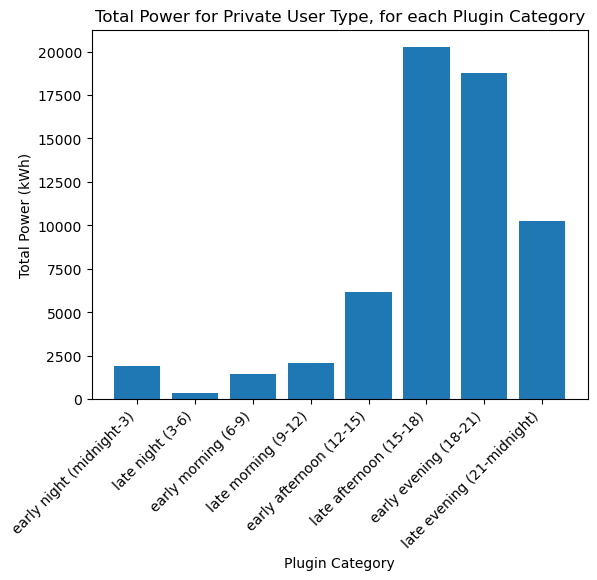

```python
# 1. Compute the total Power for Private User Type, for each Plugin Category
power_totals = (
    df.filter(df['User_type'] == 'Private')
    .groupBy('Plugin_category')
    .agg(sum('El_kWh').alias('TotalPower'))
)

# Show the computed totals
print("Total Power for Private User Type, for each Plugin Category:")
Plugin_category_mapping = {'early night (midnight-3)': 0, 'late night (3-6)': 1, 'early morning (6-9)': 2, 'late morning (9-12)': 3, 'early afternoon (12-15)': 4, 'late afternoon (15-18)': 5, 'early evening (18-21)': 6, 'late evening (21-midnight)': 7}
Plugin_category_expr = "CASE " + " ".join([f"WHEN Plugin_category = '{category}' THEN {num}" for category, num in Plugin_category_mapping.items()]) + " END"
power_totals=power_totals.withColumn("Plugin_category_num", expr(Plugin_category_expr)).orderBy("Plugin_category_num")
power_totals.select('Plugin_category','TotalPower').show(truncate=False)
# 2. Plot the values using a bar chart
categories = power_totals.select('Plugin_category').rdd.flatMap(lambda x: x).collect()
values = power_totals.select('TotalPower').rdd.flatMap(lambda x: x).collect()

plt.bar(categories, values)
plt.xlabel('Plugin Category')
plt.ylabel('Total Power (kWh)')
plt.xticks(rotation=45, ha='right')
plt.title('Total Power for Private User Type, for each Plugin Category')
plt.show()
```

1. For each charging session, calculate the **average power (electricity in kWh)** for each **duration hour**.
2. Add the above information as **a new attribute** for our dataset.
3. Show the five sessions that have **lowest average electricity per hour** based on this new attribute.

```python
# 1. Calculate the average power per hour for each charging session
df = df.withColumn("AvgPowerPerHour", expr("El_kWh / Duration_hours"))

# 2. Filter out rows with null values in AvgPowerPerHour
df = df.filter(df['AvgPowerPerHour'].isNotNull())

# 3. Show the five sessions with the lowest average electricity per hour
lowest_avg_electricity_per_hour = (
    df.orderBy('AvgPowerPerHour')
    .select('Session_ID','AvgPowerPerHour')
    .limit(5)
)

# Show the results
print("Sessions with the lowest average electricity per hour:")
lowest_avg_electricity_per_hour.show(truncate=False)
```

```
Sessions with the lowest average electricity per hour:
```

```
[Stage 55:=================================>                     (78 + 4) / 128]
```

```
+----------+--------------------+
|Session_ID|AvgPowerPerHour     |
+----------+--------------------+
|3782      |5.593014921533312E-4|
|5846      |6.638392034978404E-4|
|3331      |8.856414988398388E-4|
|886       |0.011845417445007245|
|6084      |0.016005803917451135|
+----------+--------------------+
```

One garage can have multiple users. Create a new DF that has only four attributes **(Garage ID, Number of its users, Total Power, Total Duration Hours)**, where the **"Total Power"** is the amount of Electricity in used by the garage's users.

```python
# Create a new DataFrame with desired attributes
garage_summary_df = (
    df.groupBy('Garage_ID')
    .agg(
        count('User_ID').alias('NumberOfUsers'),
        sum('El_kWh').alias('TotalPower'),
        sum('Duration_hours').alias('TotalDurationHours')
    )
)

# Show the top 10 rows
garage_summary_df.orderBy(garage_summary_df['NumberOfUsers'].desc()).show(30,truncate=False)
```

```
[Stage 58:====================================================> (125 + 3) / 128]
```

```
+---------+-------------+------------------+------------------+
|Garage_ID|NumberOfUsers|TotalPower        |TotalDurationHours|
+---------+-------------+------------------+------------------+
|Bl2      |2238         |27025.300010392442|23274.21558328299 |
|AsO2     |665          |10672.159989733249|6755.117210979108 |
|AdO1     |586          |8372.830007579178 |9473.431144030765 |
|UT9      |418          |6705.709985176101 |2004.5852776668034|
|AdO3     |379          |5239.21999966912  |5043.483881330118 |
|UT7      |311          |2517.000002015382 |3828.9161139251664|
|MS1      |270          |1763.1700023245066|3233.604734580964 |
|AsO10    |253          |3428.270005291328 |2639.259447529912 |
|NR1      |223          |1803.7500006016344|3107.574173530098 |
|SR2      |213          |3719.5299901943654|3184.7530539366417|
|MS22     |184          |2600.9299991726875|2318.0597140938044|
|UT15     |169          |1586.9199969451874|3590.128060088493 |
|UT1      |165          |1849.9100017547607|1324.2405556812882|
|AdA6     |155          |611.0699998084456 |1756.0925022130832|
|SR14     |105          |3791.260000690818 |1043.2561086323112|
|AsO8     |103          |1099.100004658103 |1336.0402804780751|
|AsO4     |103          |776.7899955343455 |1021.0469445642084|
|Ris      |99           |893.9299963917583 |1237.0019408641383|
|AdA1     |97           |926.58999581635   |984.5658349534497 |
|AsO6     |39           |259.5299996230751 |830.1174953649752 |
|UT2      |28           |352.10999963246286|317.1466685300693 |
|Bl7      |19           |865.9600012302399 |240.97916999459267|
|MS11     |14           |169.2499995790422 |115.72861000569537|
|SR4      |8            |77.28000190854073 |77.04388998821378 |
+---------+-------------+------------------+------------------+
```